# Project: Data Analyses of Patient Appointment No-Shows in Brazil

## Exploratory Data Analysis

### Research Question 1:

#### What factors are important for predicting whether or not a patient will show up for their scheduled appointment?

The list of the total number of variables from which we shall draw the important factors for predicting whether a patient will show up for their scheduled appointment are as follows

```python
# Total list
display(list(initial_df.columns))
```

```
['PatientId',
 'AppointmentID',
 'Gender',
 'Gender-codes',
 'ScheduledDay',
 'ScheduledDay-dayname',
 'ScheduledDay-daynum',
 'ScheduledDay-weekday',
 'Days_Scheduled_Appointment',
 'Weeks_Scheduled_Appointment',
 'AppointmentDay',
 'AppointmentDay-dayname',
 'AppointmentDay-daynum',
 'AppointmentDay-weekday',
 'Age',
 'Age-Group',
 'Neighbourhood',
 'Neighbourhood-codes',
 'Scholarship',
 'Hipertension',
 'Diabetes',
 'Alcoholism',
 'Handcap',
 'SMS_received',
 'No-show',
 'No-show-codes']
```

Next I will be using a machine learning Extreme Gradient boosting model to parse through the data, extrapolate observed pattern and plot the feature importances impacting whether people will show up for their appointment.

```python
import shap
from sklearn.model_selection import train_test_split
from xgboost import XGBClassifier
```

```python
feature_importance_df = initial_df.copy()
feature_importance_df = feature_importance_df[["PatientId", "AppointmentID", "Gender-codes", "ScheduledDay-daynum", "ScheduledDay-weekday", "Days_Scheduled_Appointment", "Weeks_Scheduled_Appointment", "AppointmentDay-daynum", "AppointmentDay-weekday", "Age", "Age-Group", "Neighbourhood-codes", "Scholarship", "Hipertension", "Diabetes", "Alcoholism", "Handcap", "SMS_received", "No-show-codes"]]

feature_importance_df["Age-Group"]  = feature_importance_df["Age-Group"].cat.codes
```

[output not shown]

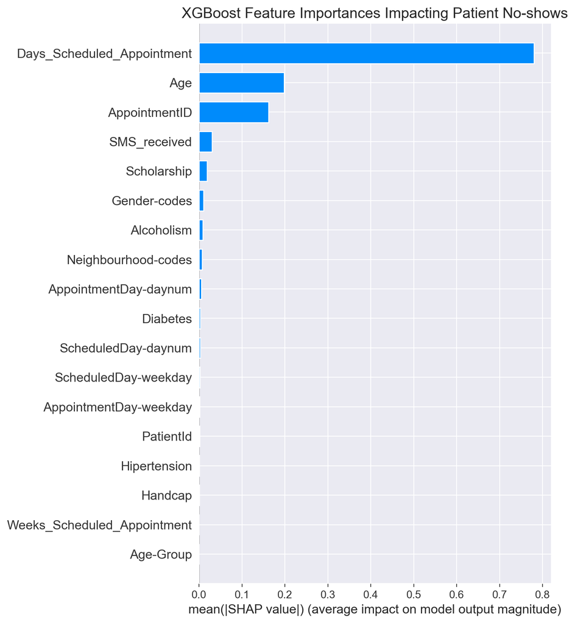

```
[('Days_Scheduled_Appointment', 0.6152781),
 ('Age', 0.061595142),
 ('SMS_received', 0.04455519),
 ('AppointmentID', 0.0403324),
 ('ScheduledDay-weekday', 0.038581125),
 ('Scholarship', 0.03129367),
 ('Gender-codes', 0.028657474),
 ('Alcoholism', 0.0253173),
 ('Handcap', 0.022598809),
 ('AppointmentDay-daynum', 0.016253749),
 ('AppointmentDay-weekday', 0.014162674),
 ('ScheduledDay-daynum', 0.013425347),
 ('Neighbourhood-codes', 0.012529826),
 ('PatientId', 0.012349178),
 ('Diabetes', 0.012019761),
 ('Hipertension', 0.011050119),
 ('Weeks_Scheduled_Appointment', 0.0),
 ('Age-Group', 0.0)]
```

```python
X_train, X_test, y_train, y_test = train_test_split(feature_importance_df.drop(columns = "No-show-codes"), feature_importance_df["No-show-codes"], test_size = 0.30, random_state = 0)

xgb = XGBClassifier(n_estimators=50)
xgb.fit(X_train, y_train)

feature_explainer = shap.TreeExplainer(xgb)
shap_values = feature_explainer.shap_values(X_test)

display(shap.summary_plot(shap_values, X_test, plot_type="bar", show = False))
plt.title('XGBoost Feature Importances Impacting Patient No-shows', fontsize = 15)
plt.show()


# display(sorted(list(xgb.feature_importances_), reverse = True))
display(sorted(list(zip(list(feature_importance_df.columns), list(xgb.feature_importances_))), key = lambda x: x[1], reverse = True))
```

From the above data visual, we can conclude that the single most important factor that impacts whether patient will show up for their appointment or not is the number of days between when patients schedule their appointment and the actual appointment date. More details will be looked into in the subsequent research questions

It is also interesting to see that the age of the patient is also a significant predictor in whether the patient will show up or not for their appointment or not.

"AppointmentID" showing up as significant implies that while it may not be obvious, recent changes in hospital operations (since more recent Appointment IDs will have larger integer numbers) are impacting whether the patient will show up for their appointment or not. This could be instrumental in providing a recommendation for a path to resolving the patient no-show issues.

Finally, whether the patient has a Scholarship or not is a predictor to whether they will show up for their appointment or not.

### Research Question 2:

#### Are there any trends or patterns in the data that can help us understand why some patients miss their appointments?

To answer this research question, a number of quick visuals will be plotted below

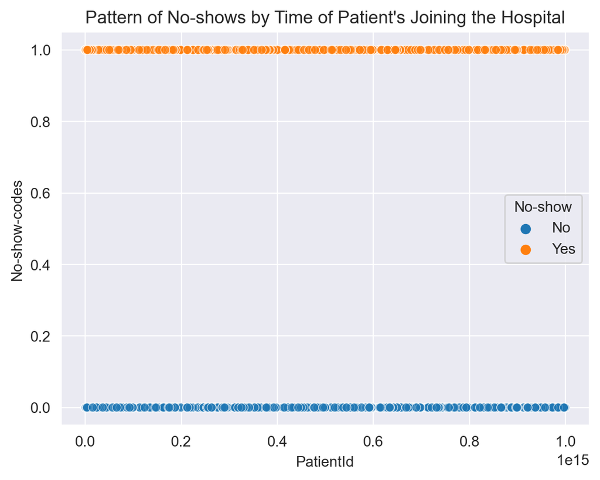

```
Correlation observed between the two variables is: 0.0015 or 0.15%
```

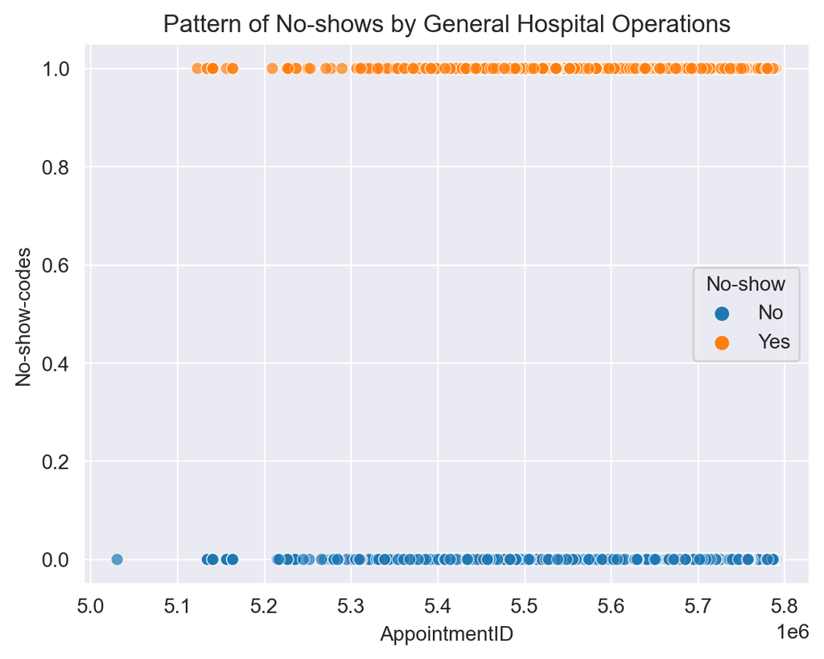

```
Correlation observed between the two variables is: 0.1626 or 16.26%
```

```python
# Plotting a scatter plot between PatientId and No-show-codes we have
plot_scatter(initial_df, "Pattern of No-shows by Time of Patient's Joining the Hospital", "PatientId")

# Plotting a scatter plot between AppointmentID and No-show-codes we have
plot_scatter(initial_df, "Pattern of No-shows by General Hospital Operations", "AppointmentID")
```

The above visuals was to establish whether there was a discernible pattern between the behaviour of earlier-registered patients to scheduled appointments and later-registered patients to scheduled appointments.

Also, the second graph was to establish whether there was any discernible pattern between number of no-shows at the earlier operations of the hospital and those observed more recently

While it can be observed that there is a higher correlation between the appointment ID, a proxy for the general hospital operations and the number of patient no-shows, it is also clear that there is no established pattern observed from either of the Patient ID and the Appointment ID.

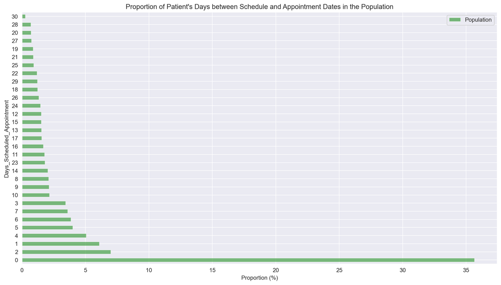

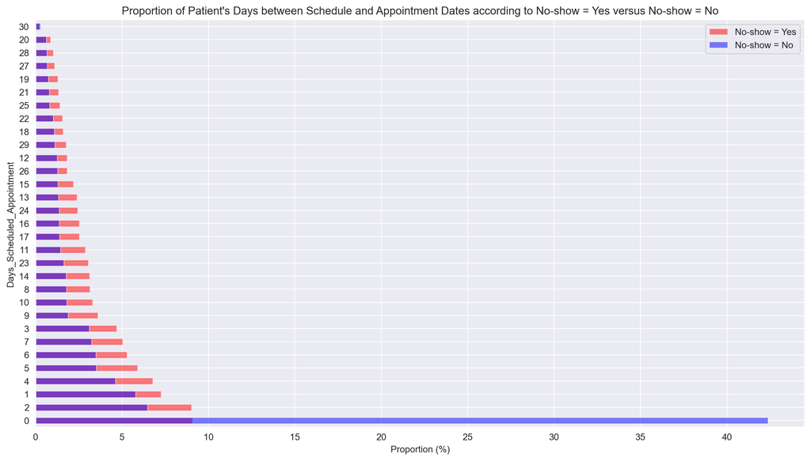

```python
compare_barchart_plot(initial_df, "Proportion of Patient's Days between Schedule and Appointment Dates in the Population", "Proportion of Patient's Days between Schedule and Appointment Dates according to No-show = Yes versus No-show = No", "Proportion (%)", "Days_Scheduled_Appointment", "Days_Scheduled_Appointment", kind="barh", figsize=(15, 8))
```

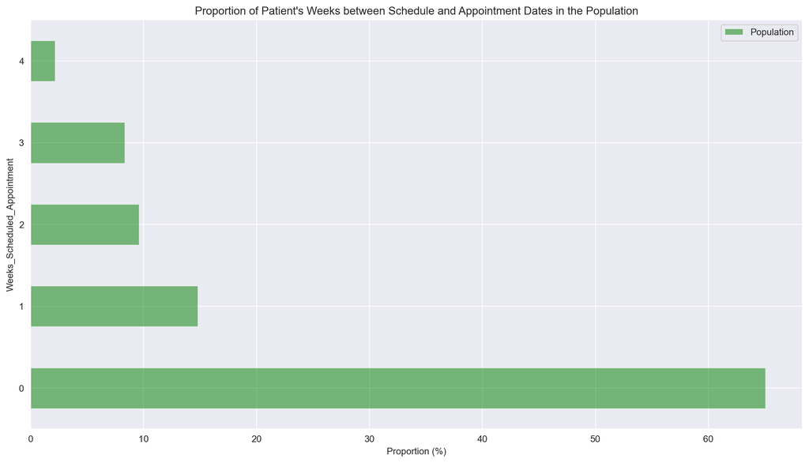

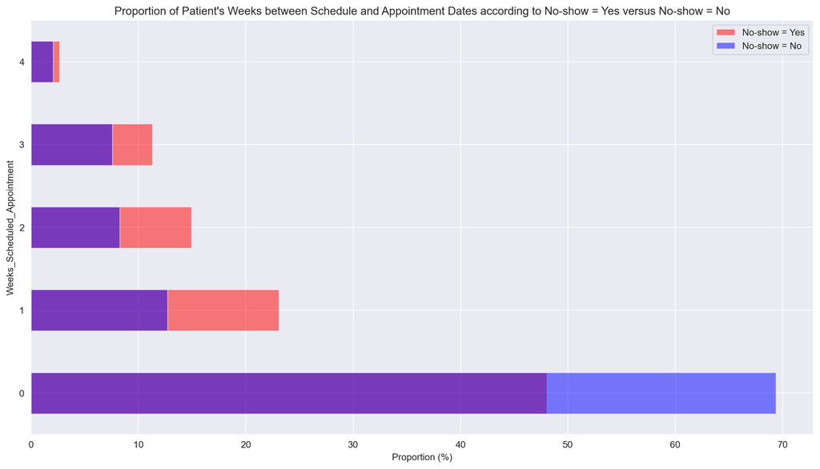

```python
compare_barchart_plot(initial_df, "Proportion of Patient's Weeks between Schedule and Appointment Dates in the Population", "Proportion of Patient's Weeks between Schedule and Appointment Dates according to No-show = Yes versus No-show = No", "Proportion (%)", "Weeks_Scheduled_Appointment", "Weeks_Scheduled_Appointment", kind="barh", figsize=(15, 8))
```

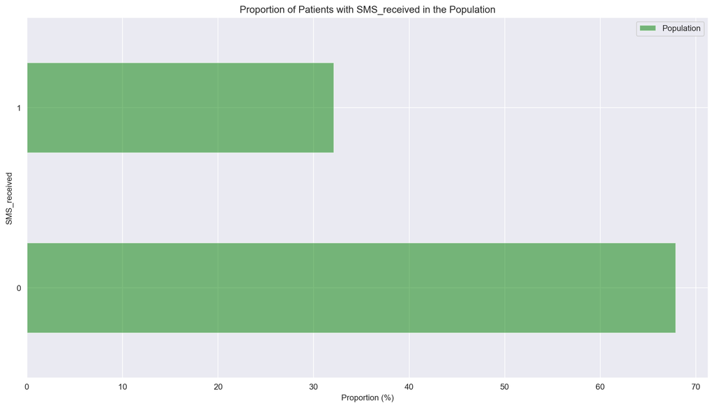

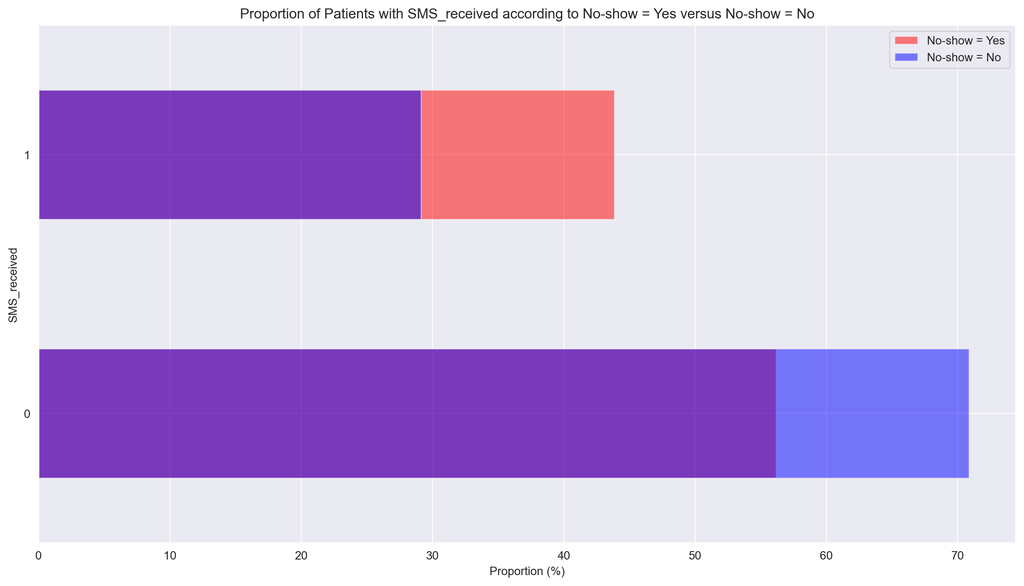

```python
compare_barchart_plot(initial_df, "Proportion of Patients with SMS_received in the Population", "Proportion of Patients with SMS_received according to No-show = Yes versus No-show = No", "Proportion (%)", "SMS_received", "SMS_received", kind="barh", figsize=(15, 8))
```

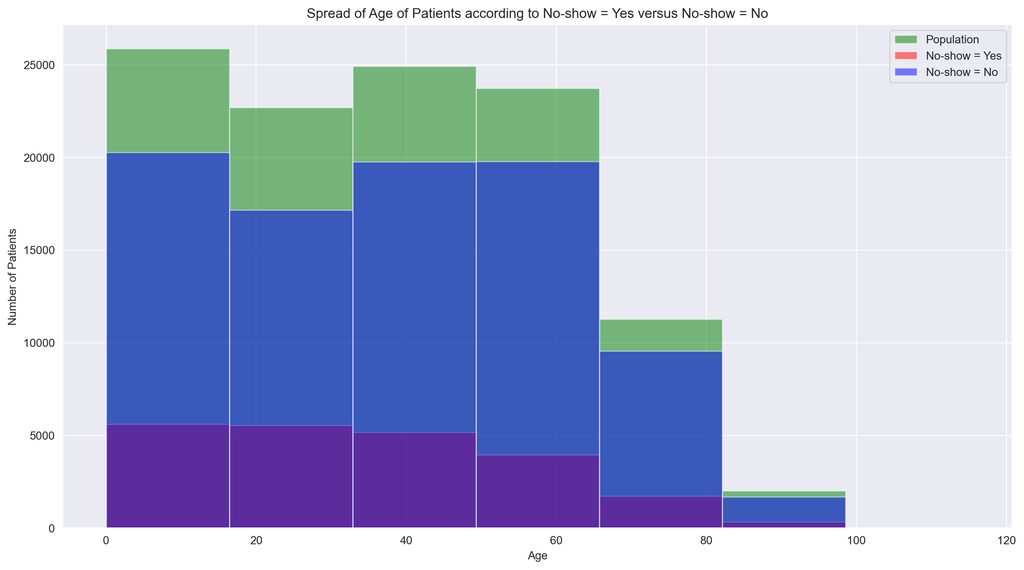

```python
compare_histogram_plot(initial_df, "Spread of Age of Patients according to No-show = Yes versus No-show = No", "Age", bins = 7, figsize=(15, 8))
```

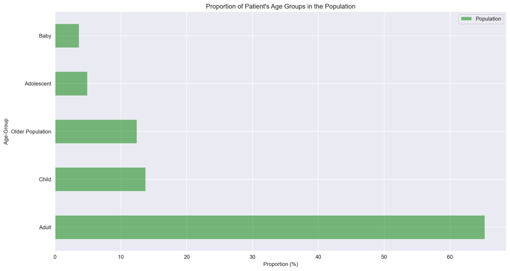

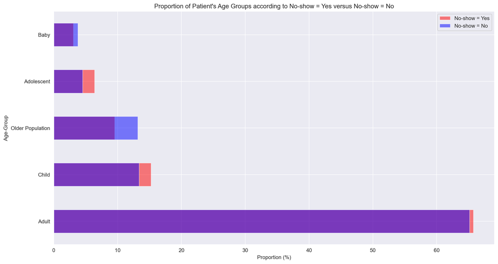

```python
compare_barchart_plot(initial_df, "Proportion of Patient's Age Groups in the Population", "Proportion of Patient's Age Groups according to No-show = Yes versus No-show = No", "Proportion (%)", "Age-Group", "Age-Group", kind="barh", figsize=(15, 8))
```

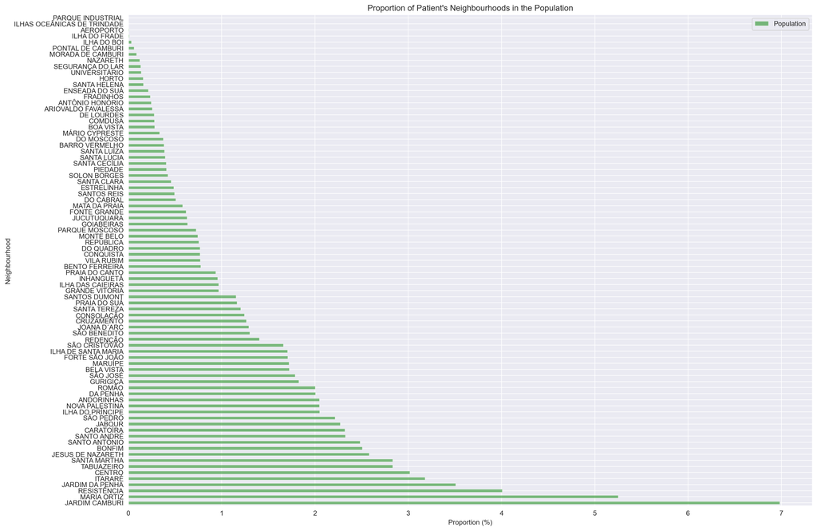

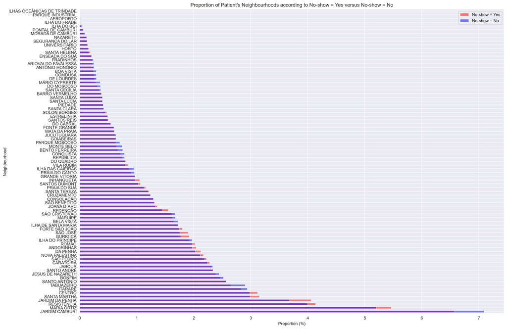

```python
compare_barchart_plot(initial_df, "Proportion of Patient's Neighbourhoods in the Population", "Proportion of Patient's Neighbourhoods according to No-show = Yes versus No-show = No", "Proportion (%)", "Neighbourhood", "Neighbourhood", kind="barh", figsize=(18, 13))
```

There are a number of other visuals produced. This can be seen in the `no_show_analyses.ipynb` notebook. However, for the sake of conciseness and relevance for this report, the above visuals have been presented.

### Research Question 3:

#### Given the statistical relationship between receiving SMS messages and attending appointments, if a more efficient bulk text system is introduced, would this significantly improve attendance of scheduled appointments?

Given the research question above, improving the SMS messaging platform will only improve the attendance of scheduled appointment if it can be established that there is a statistically significant relationship between the SMS_received and No-shows.

To answer this question on statistical significance of the variables, I will be working with the hypothesis below:

1. $H_0$: There is no statistical relationship between the SMS_recieved and the No-shows variable
2. $H_1$: There is a statistical relationship between the SMS_recieved and the No-shows variable

I will be using the Chi-square test to check the above hypothesis, using a significance level ($\alpha$) of $0.05$. Therefore, if the p-value of the test is less than or equal to the significance level, it means that $H_0$ will be rejected and if the p-value is greater than the significance level, then $H_0$ will not be rejected.

$H_0$ being rejected implies that improving the SMS messaging platform will contribute to improving the attendance of scheduled appointment.

```python
# perform the chi-square test in the function below
perform_chi_square_test(initial_df, "SMS_received", "No-show-codes")
```

| No-show-codes SMS_received | 0 | 1 | All |
| --- | --- | --- | --- |
| 0 | 62510 | 12535 | 75045 |
| 1 | 25698 | 9784 | 35482 |
| All | 88208 | 22319 | 110527 |

```
p value is 0.0


There is a statistically significant relationship between the two variables (reject H0)
```

However, it is important to state that as gleaned from some of previous analysis, simply increasing the reach of the SMS, does not guarantee that the number of no-shows will reduce. If anything, it appears that people who receive the SMS have a higher tendency to miss their appointment.

Consequently, there might be a need to look into, perhaps the contents of the SMS being sent, the timing of the sent SMS and the corresponding frequency of the messages sent. Therefore, a holistic improvement of the SMS platform together with some other measures to remind people who have booked their appointment longer into the future could positively impact the attendance rates.

## Conclusions

However, simply increasing the reach of the SMS, does not guarantee that the number of no-shows will reduce. Consequently, there might be value in looking into the contents of the SMS being sent, the timing of the sent SMS and the corresponding frequency of the messages sent. Therefore, a holistic improvement of the SMS platform together with some other measures to remind people who have booked their appointment longer into the future could positively impact the attendance rates.

### Limitations of the analysis

- This analysis was carried out to observe patterns that exist within the provided dataset. No causality analysis was carried out and the patterns observed may be symptoms of other variables not captured by the data.
- The results of this analysis are not necessarily representative of the population of patients' appointment in Brazil, as there is no information as to the accuracy and relevance of the data collected to the Brazillian population in the first place.